# Invertované repetice

Jan Chovanec

2022-05-06

# Analýza IR

Stáhnul jsem z ncbi 63 genomů, 62 pochází z Vertebrate genome project a k tomu mám lidský z projektu T2T. Tyto genomy jsem poté analyzoval pomocí Palindrome analyzeru. Výstup z PA jsem jsem profiltroval pomocí python skriptu, tak aby se mi IR nepřekrývaly, pokud došlo k překryvu zachovala se repetice, která je delší, má méně mismatchů, má menší space (v tomto pořadí). Z ncbi jsem poté stáhnul ke všem genomům Genbank soubor s anotacemi genů. Poté jsem pomocí python skriptu vybral IR, které se nacházely v blízkosti (do 1kb) počátků a konců genů, v genbank souboru jsem pro vyhledávání použil kličové slovo “gene” a používal jsem pouze geny delší než 2kb. (PA; IR Filter.py; IR2TSS.py; IR2TTS.py)

Nastavení palindrome analyzeru: Délka repetice: 10-50 Délka spaceru: 0-10 Mismatch: 0-1

## Porovnání četnosti IR s náhodnými genomy

Pro několik živočichů jsem vytvořil set 10 náhodných genomů, které jsem analyzoval stejně jako normální genomy a porovnal jsem množství nalezených IR. Jelikož u Bufo Bufo mi nevyšel test normálního rozložení použil jsem Wilcoxonův test. Živočichové byli vybrání tak aby byly zastoupeny všechny třídy a uvnitř tříd byli vybraní náhodně. (Model_gen.py; Seq_gen.py; PA; IR Filter.py)

p hodnoty Wilcoxonova testu

| Živočich | p-hodnota |
| --- | --- |
| Amblyraja radiata | 0.0019531 |
| Aquila chrysaetos | 0.0019531 |
| Asterias rubens | 0.0019531 |
| Aythya fuligula | 0.0019531 |
| Balaenoptera musculus | 0.0019531 |
| Bufo bufo | 0.0019531 |
| Carcharodon carcharias | 0.0019531 |
| Cyclopterus lumpus | 0.0019531 |
| Dermochelys coriacea | 0.0019531 |
| Falco rusticolus | 0.0019531 |
| Gopherus evgoodei | 0.0019531 |
| Chanos chanos | 0.0019531 |
| Chelonia mydas | 0.0019531 |
| Chiroxiphia lanceolata | 0.0019531 |
| Lacerta agilis | 0.0019531 |
| Lynx canadensis | 0.0019531 |
| Mustela erminea | 0.0019531 |
| Myripristis murdjan | 0.0019531 |
| Petromyzon marinus | 0.0019531 |
| Syngnathus acus | 0.0019531 |
| Trichosurus vulpecula | 0.0019531 |

### Graf

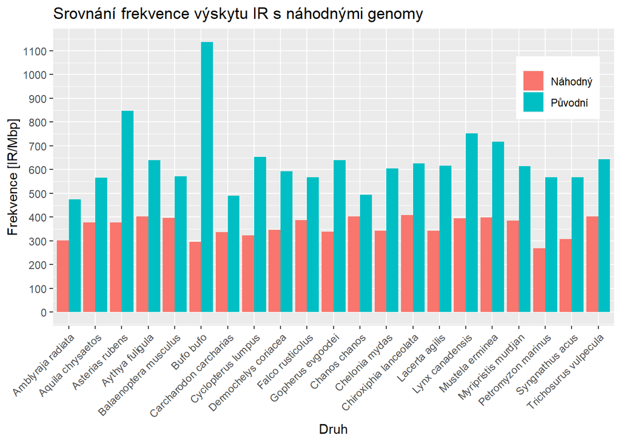

# Porovnání rozložení mezi třídami

Porovnal jsem frekvenci výskytu IR v genomu mezi taxonomickými třídami. Vybral jsem 5 tříd s dostatečným počtem zástupců: Obojživelníci (n=5) Plazi (n=5) Ptáci (n=11) Ryby (n=23) Savci (n=15).

Pozice IR je určena jejím 5’ koncem (tzn. IR s celkovou délkou 20 bp ve vzdálenosti 10 bp upstream od TSS bude přesahovat do genu 10 bázemi.) (“ALL summaries to one file.py”)

## Test normálního rozložení uvnitř tříd

U některých skupin opět nebylo normální rozložení. Tak jsem na srovnání použil Kruskal-Wallisův test. Výsledek testu je uveden pod každým grafem. Dále jsem provedl Dunnův test s Holm-Bonferonniho korekcí, abych porovnal jednotlivé třídy mezi sebou, výsledky jsou uvedeny v tabulkách pod grafy, červeně zvýrazněné jsou hodnoty, které NEJSOU statisticky významné.

p hodnoty Shapiro-Wilkova testu

|  | Plazi | Ptáci | Ryby | Savci | Obojživelníci |
| --- | --- | --- | --- | --- | --- |
| Celý genom | 0.0205378 | 0.5599680 | 0.0000781 | 0.8331904 | 0.2891196 |
| TSS upstream | 0.1501735 | 0.5138997 | 0.0127765 | 0.0652816 | 0.1546197 |
| TSS downstream | 0.8355769 | 0.6794927 | 0.0119874 | 0.9250323 | 0.0832120 |
| TTS upstream | 0.3772030 | 0.0122076 | 0.5921219 | 0.0000995 | 0.0715280 |
| TTS downstream | 0.0149442 | 0.0865752 | 0.3793043 | 0.1850452 | 0.0963667 |

## Celý genom

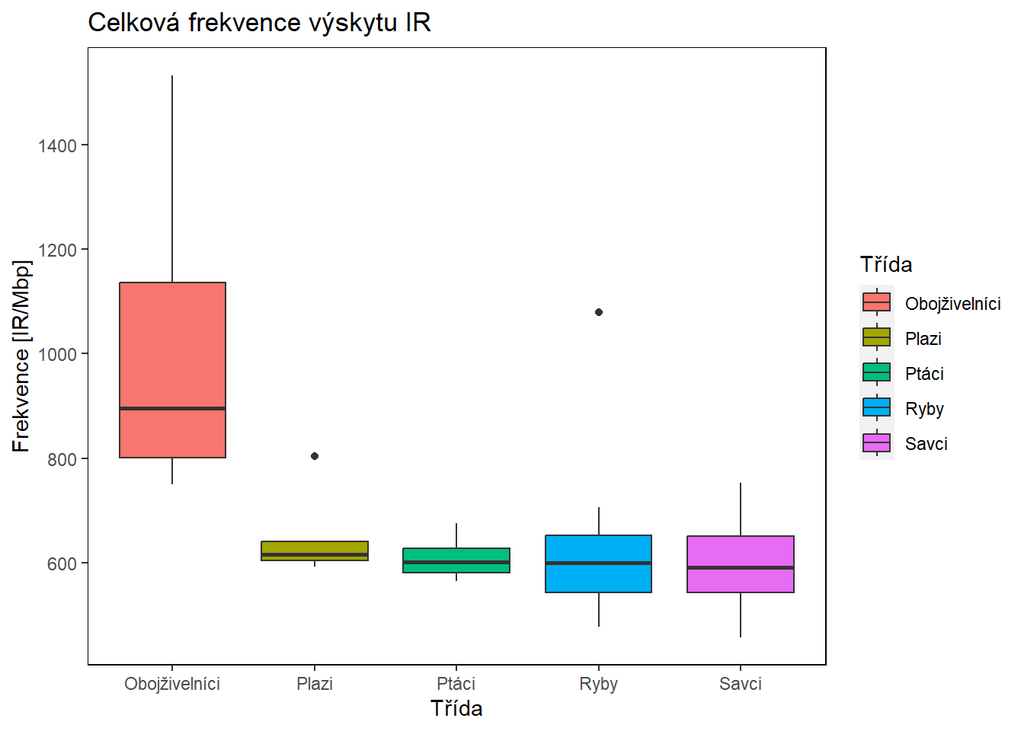

```
##
##  Kruskal-Wallis rank sum test
##
## data:  IR.Mbp by Třída
## Kruskal-Wallis chi-squared = 13.47, df = 4, p-value = 0.009192
```

Dunnův test

| Srovnání | Z | p-hodnota | Holm-Bonferonniho korekce |
| --- | --- | --- | --- |
| Obojživelníci - Plazi | 1.9332067 | 0.0532107 | 0.3724752 |
| Obojživelníci - Ptáci | 3.0205517 | 0.0025231 | 0.0201852 |
| Plazi - Ptáci | 0.7536659 | 0.4510498 | 1.0000000 |
| Obojživelníci - Ryby | 3.3469175 | 0.0008172 | 0.0073544 |
| Plazi - Ryby | 0.8690494 | 0.3848201 | 1.0000000 |
| Ptáci - Ryby | 0.0608921 | 0.9514451 | 0.9514451 |
| Obojživelníci - Savci | 3.4350223 | 0.0005925 | 0.0059250 |
| Plazi - Savci | 1.0673374 | 0.2858195 | 1.0000000 |
| Ptáci - Savci | 0.3644552 | 0.7155181 | 1.0000000 |
| Ryby - Savci | 0.3686597 | 0.7123814 | 1.0000000 |

## Počátek transkripce upstream

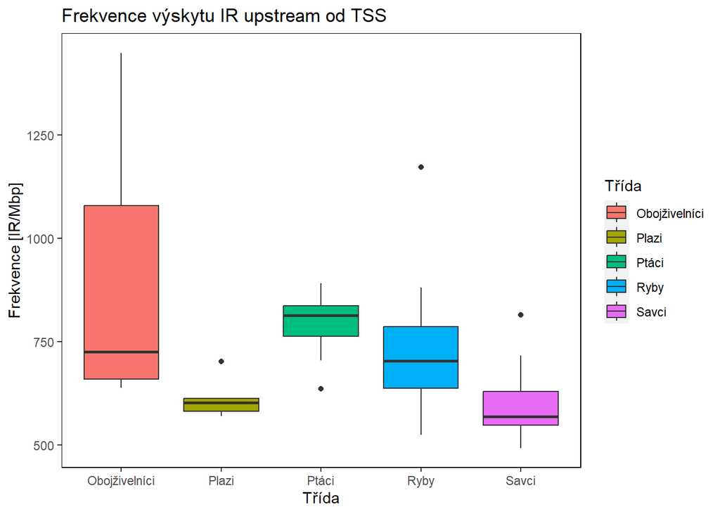

```
##
##  Kruskal-Wallis rank sum test
##
## data:  TSS.upstream.IR.Mbp by Třída
## Kruskal-Wallis chi-squared = 24.384, df = 4, p-value = 6.689e-05
```

Dunnův test

| Srovnání | Z | p-hodnota | Holm-Bonferonniho korekce |
| --- | --- | --- | --- |
| Obojživelníci - Plazi | 2.1173216 | 0.0342326 | 0.2053954 |
| Obojživelníci - Ptáci | -0.4219744 | 0.6730437 | 1.0000000 |
| Plazi - Ptáci | -2.9047541 | 0.0036754 | 0.0294033 |
| Obojživelníci - Ryby | 0.9798609 | 0.3271548 | 0.9814644 |
| Plazi - Ryby | -1.7339947 | 0.0829190 | 0.3316761 |
| Ptáci - Ryby | 1.9397589 | 0.0524090 | 0.2620450 |
| Obojživelníci - Savci | 2.9013537 | 0.0037155 | 0.0260088 |
| Plazi - Savci | 0.3081749 | 0.7579493 | 0.7579493 |
| Ptáci - Savci | 4.3476844 | 0.0000138 | 0.0001376 |
| Ryby - Savci | 3.0575872 | 0.0022313 | 0.0200814 |

## Počátek transkripce downstream

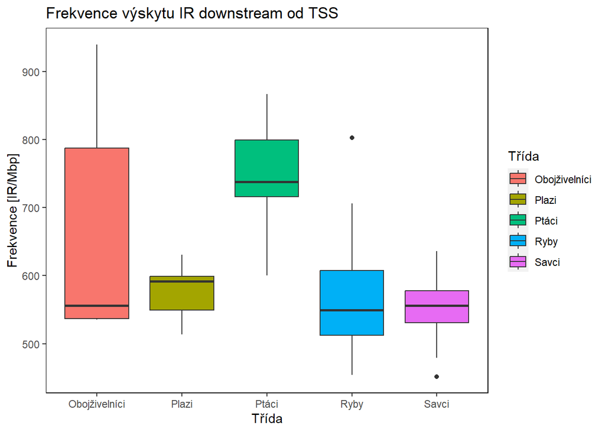

```
##
##  Kruskal-Wallis rank sum test
##
## data:  TSS.downstream.IR.Mbp by Třída
## Kruskal-Wallis chi-squared = 21.377, df = 4, p-value = 0.0002666
```

Dunnův test

| Srovnání | Z | p-hodnota | Holm-Bonferonniho korekce |
| --- | --- | --- | --- |
| Obojživelníci - Plazi | 0.5523448 | 0.5807122 | 1.0000000 |
| Obojživelníci - Ptáci | -1.7212631 | 0.0852031 | 0.5964217 |
| Plazi - Ptáci | -2.3689447 | 0.0178389 | 0.1427114 |
| Obojživelníci - Ryby | 1.2558636 | 0.2091654 | 1.0000000 |
| Plazi - Ryby | 0.5479013 | 0.5837597 | 1.0000000 |
| Ptáci - Ryby | 4.2228991 | 0.0000241 | 0.0002412 |
| Obojživelníci - Savci | 1.2928312 | 0.1960695 | 1.0000000 |
| Plazi - Savci | 0.6163497 | 0.5376637 | 1.0000000 |
| Ptáci - Savci | 4.0205636 | 0.0000581 | 0.0005225 |
| Ryby - Savci | 0.1444129 | 0.8851744 | 0.8851744 |

## Konec transkripce upstream

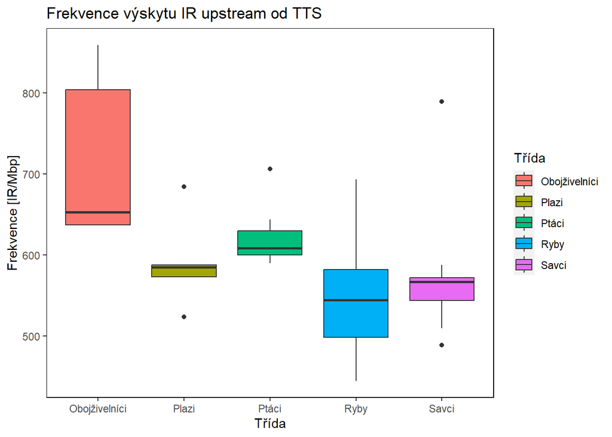

```
##
##  Kruskal-Wallis rank sum test
##
## data:  TTS.upstream.IR.Mbp by Třída
## Kruskal-Wallis chi-squared = 26.381, df = 4, p-value = 2.652e-05
```

Dunnův test

| Srovnání | Z | p-hodnota | Holm-Bonferonniho korekce |
| --- | --- | --- | --- |
| Obojživelníci - Plazi | 1.9884412 | 0.0467629 | 0.2805775 |
| Obojživelníci - Ptáci | 1.0029252 | 0.3158969 | 0.6317939 |
| Plazi - Ptáci | -1.3287287 | 0.1839375 | 0.9196874 |
| Obojživelníci - Ryby | 3.8763502 | 0.0001060 | 0.0010604 |
| Plazi - Ryby | 1.3276859 | 0.1842819 | 0.7371276 |
| Ptáci - Ryby | 3.7420397 | 0.0001825 | 0.0016428 |
| Obojživelníci - Savci | 3.4726046 | 0.0005154 | 0.0041235 |
| Plazi - Savci | 1.0372715 | 0.2996093 | 0.8988280 |
| Ptáci - Savci | 3.1547601 | 0.0016063 | 0.0112441 |
| Ryby - Savci | -0.3600153 | 0.7188357 | 0.7188357 |

## Konec transkripce downstream

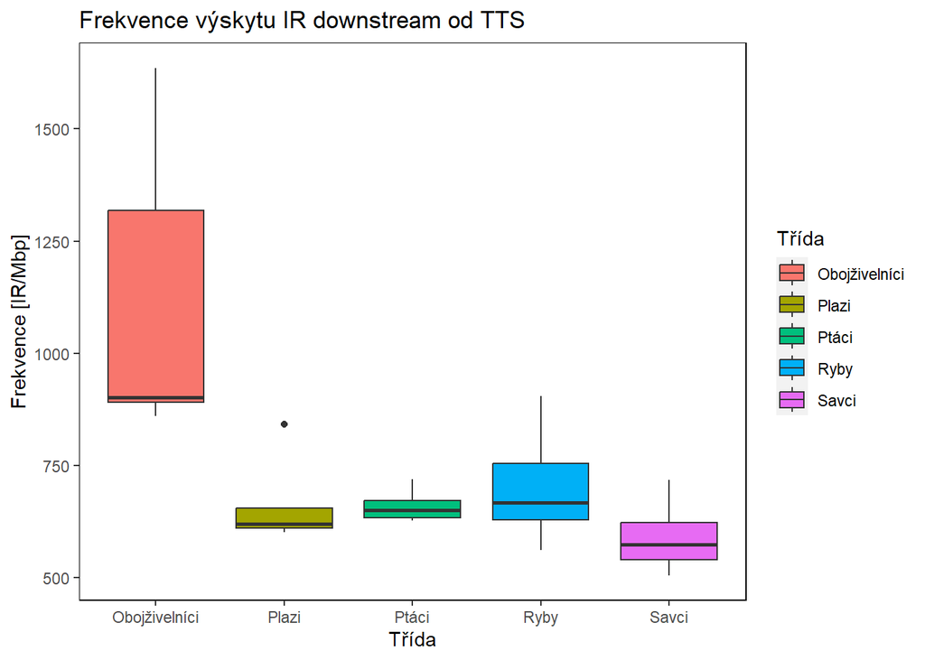

```
##
##  Kruskal-Wallis rank sum test
##
## data:  TTS.downstream.IR.Mbp by Třída
## Kruskal-Wallis chi-squared = 24.02, df = 4, p-value = 7.915e-05
```

Dunnův test

| Srovnání | Z | p-hodnota | Holm-Bonferonniho korekce |
| --- | --- | --- | --- |
| Obojživelníci - Plazi | 2.7433124 | 0.0060823 | 0.0425760 |
| Obojživelníci - Ptáci | 2.7909191 | 0.0052559 | 0.0420469 |
| Plazi - Ptáci | -0.4258998 | 0.6701809 | 0.6701809 |
| Obojživelníci - Ryby | 2.6225387 | 0.0087277 | 0.0523664 |
| Plazi - Ryby | -0.8936742 | 0.3714962 | 1.0000000 |
| Ptáci - Ryby | -0.5762779 | 0.5644274 | 1.0000000 |
| Obojživelníci - Savci | 4.6075902 | 0.0000041 | 0.0000407 |
| Plazi - Savci | 1.2477324 | 0.2121291 | 0.8485163 |
| Ptáci - Savci | 2.2018430 | 0.0276764 | 0.1383820 |
| Ryby - Savci | 3.2701386 | 0.0010749 | 0.0096745 |

# Analýza IR v blízkosti genů podle funkce genu

Stáhnul jsem si z kegg.jp anotace genů a určil jsem podle toho kolik genů s IR se nachází v základních kegg kategoriích. Jelikož se v různých skupinách nachází různé počty genů použil jsem poměr mezi geny s IR a celkovým počtem genů v dané kategorii. Mám zde dvě sady grafů, první znázorňují poměr počtu IR vůči počtu genů v kategorii a druhá sada ukazuje poměr počtu genů s IR vůči celkovému počtu genů. (all_gene_extractor.py; kegg_get.py; kegg_brite.py; kegg_counter.py)

## Relativní počet IR u jednotlivých skupin genů

Relativní počet IR = Počet IR / Počet genů ve skupině

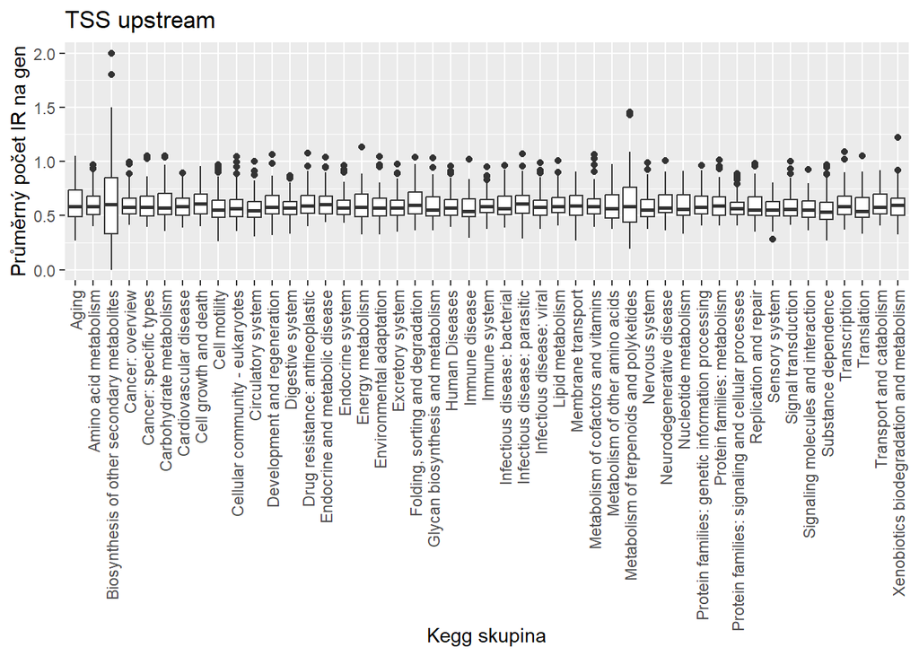

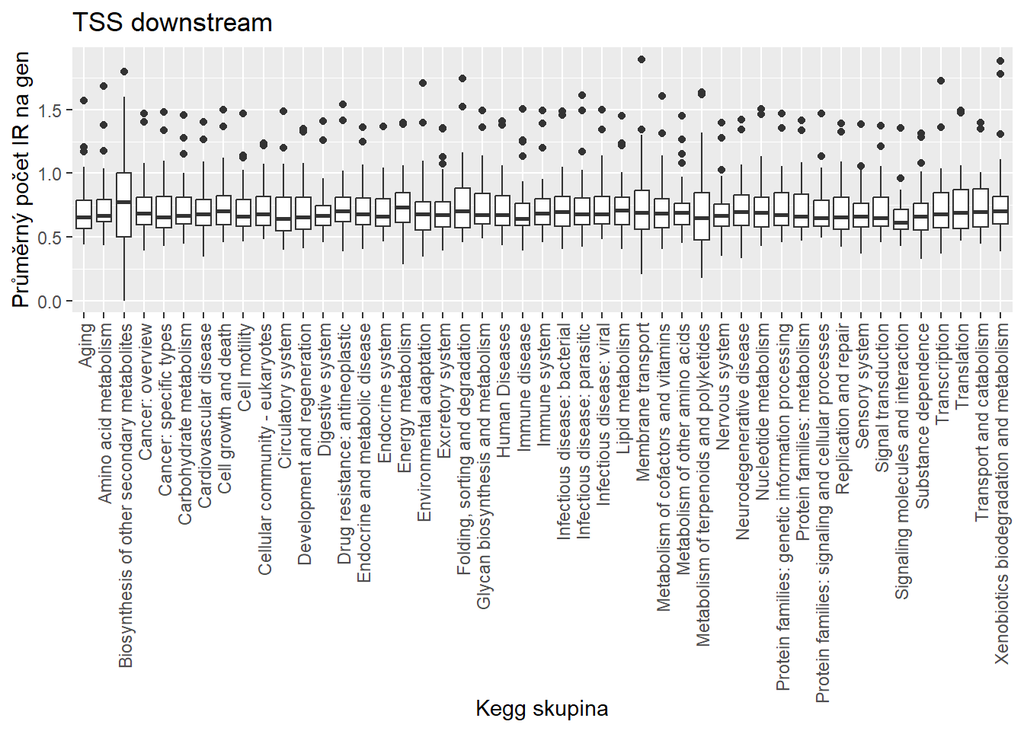

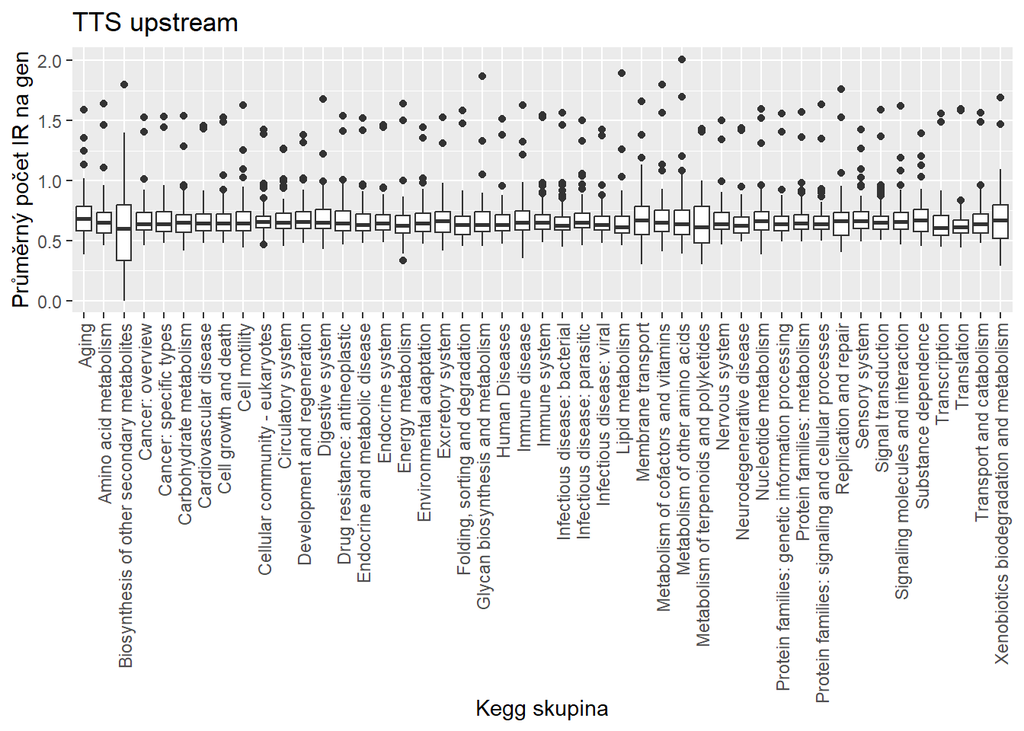

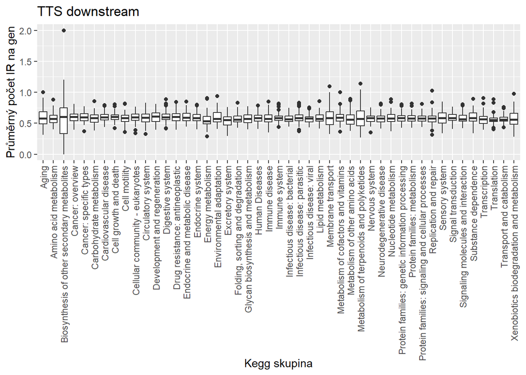

## Poměr genů s IR a bez IR v rámci jednotlivých skupin genů

Poměr = Počet genů s IR / Celkový počet genů ve skupině

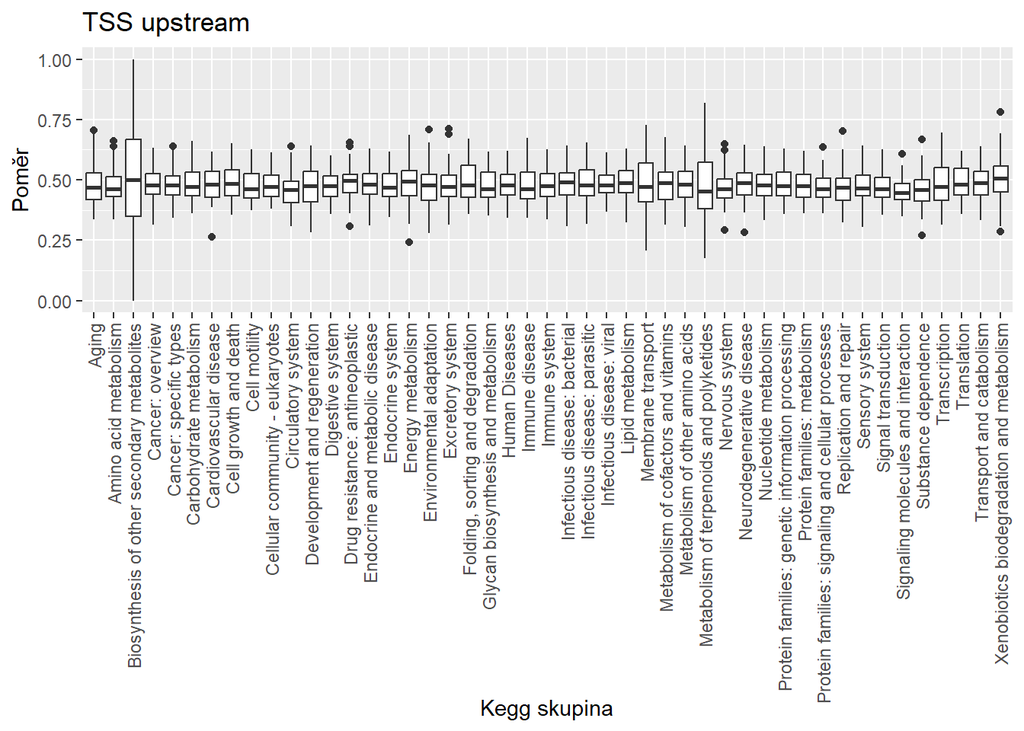

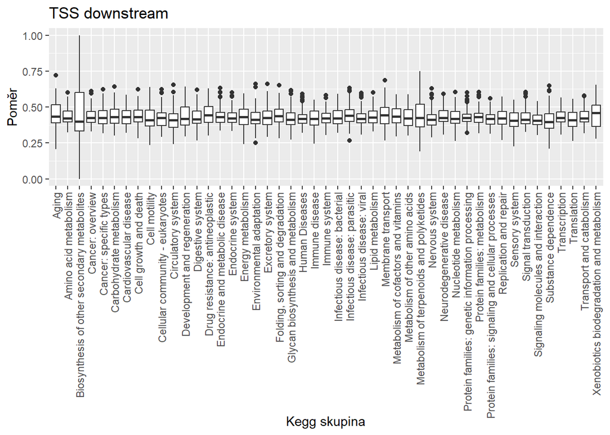

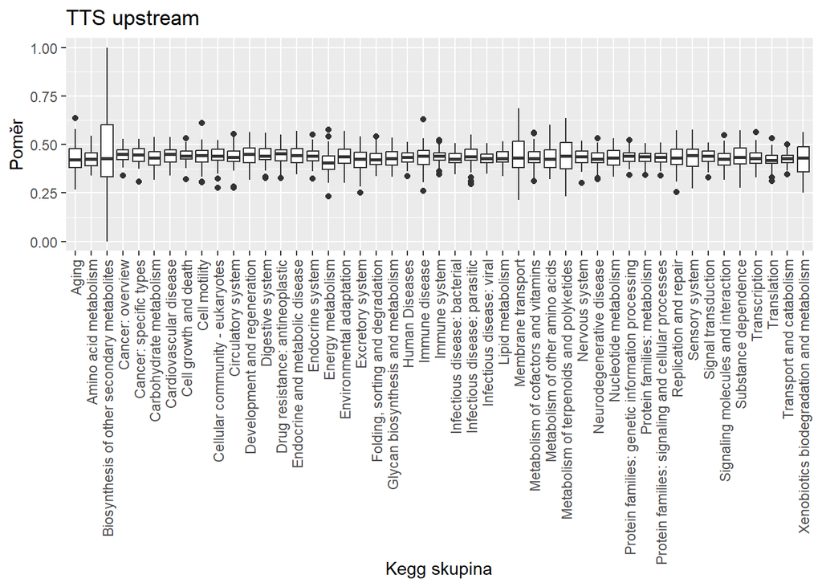

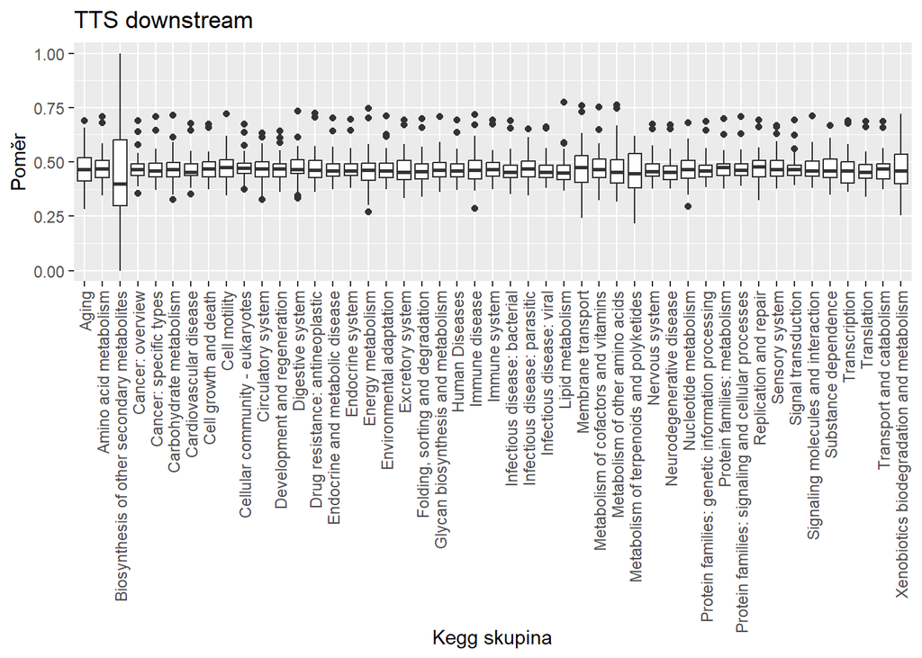

# Porovnání kegg “Protein families” mezi druhy

Grafy znázorňují poměr mezi počtem genů s IR a celkovým počtem genů v dané “Protein family”

## Test normálního rozložení

U plazů nevychází je nutné použít kruskal-wallisův test

p hodnoty Shapiro-Wilkova testu

|  | Plazi | Ptáci | Ryby | Savci | Obojživelníci |
| --- | --- | --- | --- | --- | --- |
| TSS upstream | 0.2277433 | 0.4342062 | 0.6545149 | 0.8643636 | 0.1487181 |
| TSS downstream | 0.0177268 | 0.5364819 | 0.4030622 | 0.1495493 | 0.9958185 |
| TTS upstream | 0.8734083 | 0.1817294 | 0.4207330 | 0.7929430 | 0.3887204 |
| TTS downstream | 0.1184910 | 0.1680795 | 0.4223729 | 0.8690338 | 0.4236488 |

# Protein families

U Brite Hierarchie “Protein family” byl vyhodnocen počet genů s (alespoň jednou) repeticí a počet genů bez repetice v dané kategorii (poměr s IR vs celkový počet). Zároveň byl proveden kruskal-wallisův test, u všech je statisticky významný rozdíl. Poté byl proveden Dunnův test s holm-bonferonniho korekcí aby bylo zjištěno, které konkrétní dvojice se liší.

## Metabolismus

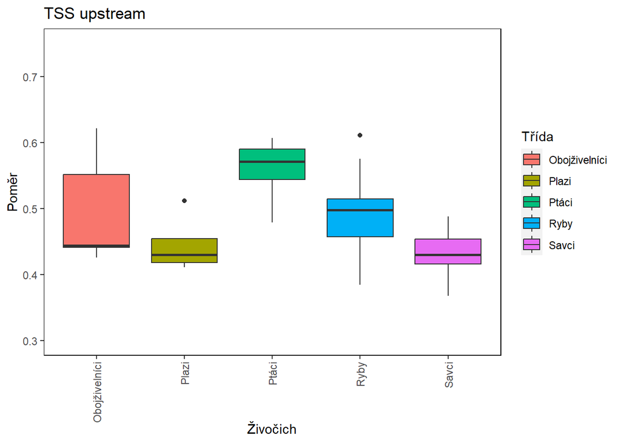

```
##
##  Kruskal-Wallis rank sum test
##
## data:  value by Třída
## Kruskal-Wallis chi-squared = 26.31, df = 4, p-value = 2.741e-05
```

Dunnův test TSSup

| Srovnání | Z | p-hodnota | Holm-Bonferonniho korekce |
| --- | --- | --- | --- |
| Obojživelníci - Plazi | 1.1048482 | 0.2692253 | 0.8076760 |
| Obojživelníci - Ptáci | -2.0201787 | 0.0433649 | 0.2601891 |
| Plazi - Ptáci | -3.3157282 | 0.0009140 | 0.0082264 |
| Obojživelníci - Ryby | -0.2828082 | 0.7773239 | 0.7773239 |
| Plazi - Ryby | -1.6989363 | 0.0893312 | 0.4466560 |
| Ptáci - Ryby | 2.5916118 | 0.0095527 | 0.0668692 |
| Obojživelníci - Savci | 1.6513752 | 0.0986620 | 0.3946480 |
| Plazi - Savci | 0.3101403 | 0.7564543 | 1.0000000 |
| Ptáci - Savci | 4.8396490 | 0.0000013 | 0.0000130 |
| Ryby - Savci | 2.9497225 | 0.0031806 | 0.0254448 |

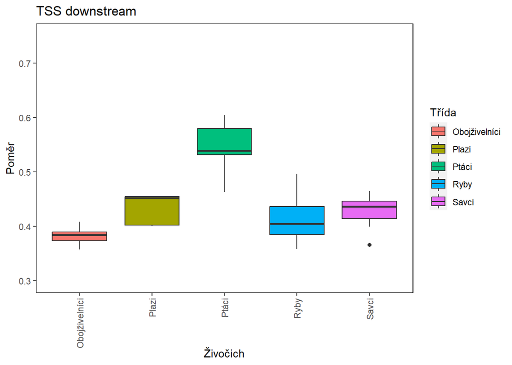

```
##
##  Kruskal-Wallis rank sum test
##
## data:  value by Třída
## Kruskal-Wallis chi-squared = 31.796, df = 4, p-value = 2.106e-06
```

Dunnův test TSSdown

| Srovnání | Z | p-hodnota | Holm-Bonferonniho korekce |
| --- | --- | --- | --- |
| Obojživelníci - Plazi | -1.9662554 | 0.0492691 | 0.2463456 |
| Obojživelníci - Ptáci | -4.6252511 | 0.0000037 | 0.0000337 |
| Plazi - Ptáci | -2.3196124 | 0.0203619 | 0.1425330 |
| Obojživelníci - Ryby | -1.3576880 | 0.1745627 | 0.5236881 |
| Plazi - Ryby | 1.1625399 | 0.2450162 | 0.4900324 |
| Ptáci - Ryby | 4.9776314 | 0.0000006 | 0.0000064 |
| Obojživelníci - Savci | -2.1726057 | 0.0298100 | 0.1788600 |
| Plazi - Savci | 0.2143378 | 0.8302837 | 0.8302837 |
| Ptáci - Savci | 3.3823144 | 0.0007188 | 0.0057502 |
| Ryby - Savci | -1.3628293 | 0.1729363 | 0.6917453 |

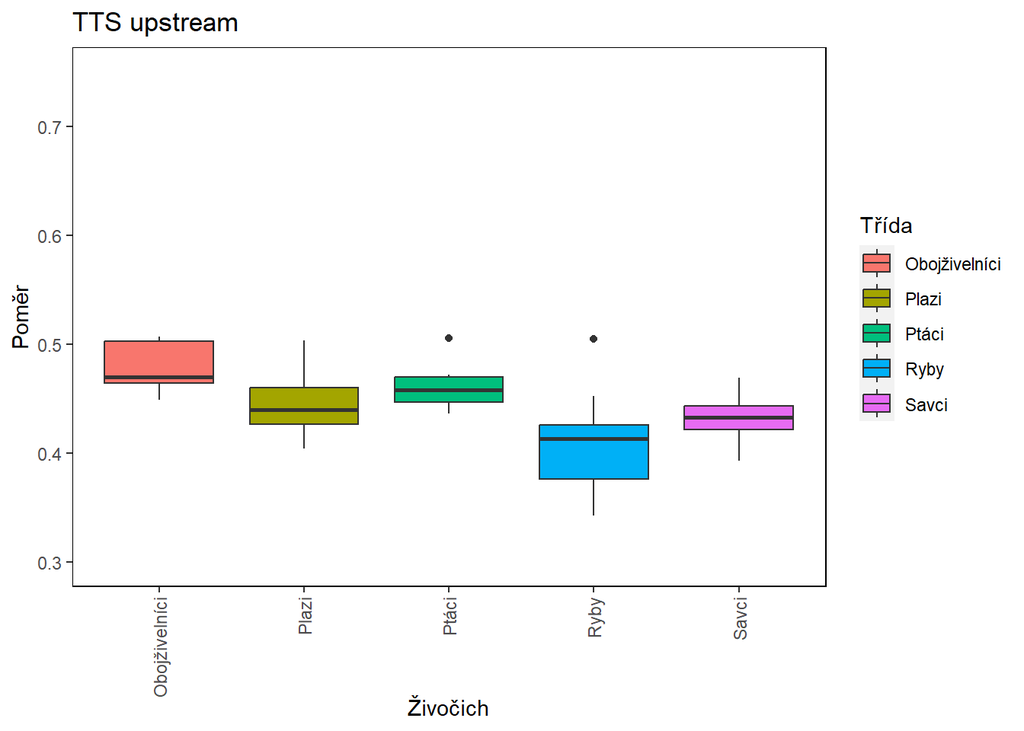

```
##
##  Kruskal-Wallis rank sum test
##
## data:  value by Třída
## Kruskal-Wallis chi-squared = 26.937, df = 4, p-value = 2.047e-05
```

Dunnův test TTSup

| Srovnání | Z | p-hodnota | Holm-Bonferonniho korekce |
| --- | --- | --- | --- |
| Obojživelníci - Plazi | 1.5355518 | 0.1246483 | 0.4985934 |
| Obojživelníci - Ptáci | 0.6827086 | 0.4947910 | 0.4947910 |
| Plazi - Ptáci | -1.1178855 | 0.2636159 | 0.7908477 |
| Obojživelníci - Ryby | 3.8726981 | 0.0001076 | 0.0009687 |
| Plazi - Ryby | 1.9045201 | 0.0568425 | 0.3410549 |
| Ptáci - Ryby | 4.2082566 | 0.0000257 | 0.0002573 |
| Obojživelníci - Savci | 2.5947862 | 0.0094650 | 0.0757198 |
| Plazi - Savci | 0.7306970 | 0.4649643 | 0.9299285 |
| Ptáci - Savci | 2.4412980 | 0.0146346 | 0.1024420 |
| Ryby - Savci | -1.6492838 | 0.0990895 | 0.4954475 |

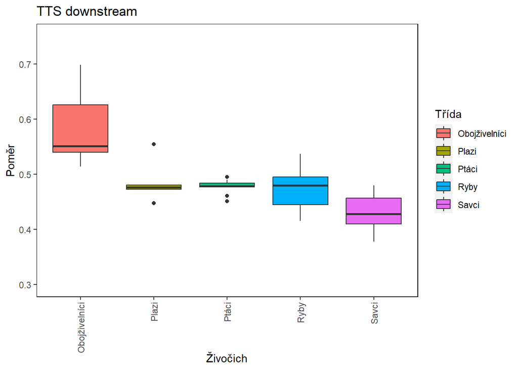

```
##
##  Kruskal-Wallis rank sum test
##
## data:  value by Třída
## Kruskal-Wallis chi-squared = 25.621, df = 4, p-value = 3.772e-05
```

Dunnův test TTSdown

| Srovnání | Z | p-hodnota | Holm-Bonferonniho korekce |
| --- | --- | --- | --- |
| Obojživelníci - Plazi | 2.0224341 | 0.0431315 | 0.1725261 |
| Obojživelníci - Ptáci | 2.3056388 | 0.0211308 | 0.1267849 |
| Plazi - Ptáci | -0.0658754 | 0.9474770 | 0.9474770 |
| Obojživelníci - Ryby | 2.8959141 | 0.0037806 | 0.0264639 |
| Plazi - Ryby | 0.3036796 | 0.7613720 | 1.0000000 |
| Ptáci - Ryby | 0.5056804 | 0.6130811 | 1.0000000 |
| Obojživelníci - Savci | 4.7495304 | 0.0000020 | 0.0000204 |
| Plazi - Savci | 2.2943885 | 0.0217682 | 0.1088410 |
| Ptáci - Savci | 3.0549628 | 0.0022509 | 0.0180071 |
| Ryby - Savci | 3.0842693 | 0.0020405 | 0.0183648 |

## Zpracování genetické informace

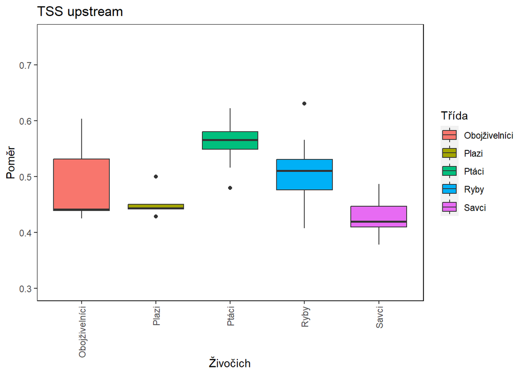

```
##
##  Kruskal-Wallis rank sum test
##
## data:  value by Třída
## Kruskal-Wallis chi-squared = 31.845, df = 4, p-value = 2.058e-06
```

Dunnův test TSSup

| Srovnání | Z | p-hodnota | Holm-Bonferonniho korekce |
| --- | --- | --- | --- |
| Obojživelníci - Plazi | 0.6741447 | 0.5002193 | 0.5002193 |
| Obojživelníci - Ptáci | -2.2297823 | 0.0257619 | 0.1545714 |
| Plazi - Ptáci | -3.0202870 | 0.0025254 | 0.0202028 |
| Obojživelníci - Ryby | -0.7628516 | 0.4455519 | 0.8911038 |
| Plazi - Ryby | -1.6269297 | 0.1037520 | 0.4150081 |
| Ptáci - Ryby | 2.2538531 | 0.0242054 | 0.1694379 |
| Obojživelníci - Savci | 1.8137523 | 0.0697159 | 0.3485794 |
| Plazi - Savci | 0.9953717 | 0.3195555 | 0.9586666 |
| Ptáci - Savci | 5.3301991 | 0.0000001 | 0.0000010 |
| Ryby - Savci | 3.8980607 | 0.0000970 | 0.0008727 |

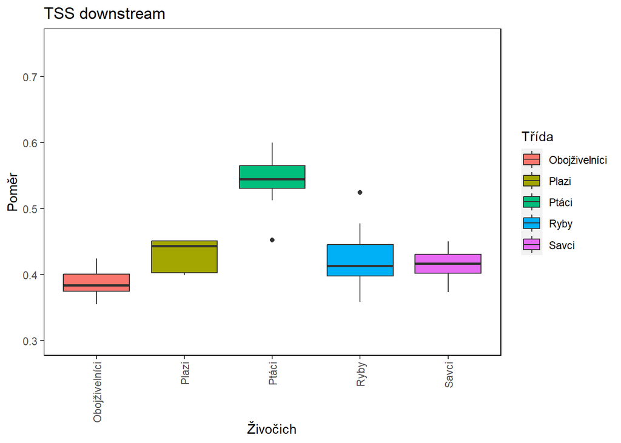

```
##
##  Kruskal-Wallis rank sum test
##
## data:  value by Třída
## Kruskal-Wallis chi-squared = 28.706, df = 4, p-value = 8.97e-06
```

Dunnův test TSSdown

| Srovnání | Z | p-hodnota | Holm-Bonferonniho korekce |
| --- | --- | --- | --- |
| Obojživelníci - Plazi | -1.7415405 | 0.0815889 | 0.4895333 |
| Obojživelníci - Ptáci | -4.4515796 | 0.0000085 | 0.0000852 |
| Plazi - Ptáci | -2.4094424 | 0.0159769 | 0.1118384 |
| Obojživelníci - Ryby | -1.5966661 | 0.1103401 | 0.5517007 |
| Plazi - Ryby | 0.6355357 | 0.5250791 | 1.0000000 |
| Ptáci - Ryby | 4.4004407 | 0.0000108 | 0.0000972 |
| Obojživelníci - Savci | -1.3802054 | 0.1675234 | 0.6700936 |
| Plazi - Savci | 0.7339445 | 0.4629825 | 1.0000000 |
| Ptáci - Savci | 4.1744478 | 0.0000299 | 0.0002390 |
| Ryby - Savci | 0.2029053 | 0.8392090 | 0.8392090 |

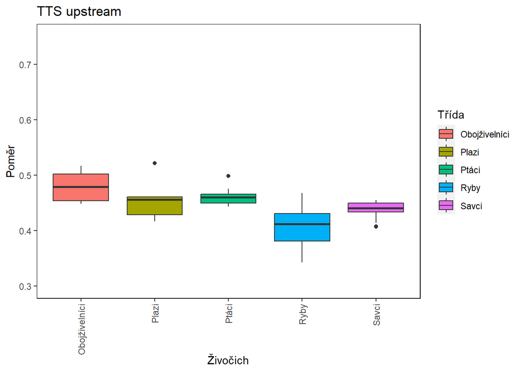

```
##
##  Kruskal-Wallis rank sum test
##
## data:  value by Třída
## Kruskal-Wallis chi-squared = 29.803, df = 4, p-value = 5.369e-06
```

Dunnův test TTSup

| Srovnání | Z | p-hodnota | Holm-Bonferonniho korekce |
| --- | --- | --- | --- |
| Obojživelníci - Plazi | 1.0861220 | 0.2774250 | 1.0000000 |
| Obojživelníci - Ptáci | 0.5309956 | 0.5954218 | 0.5954218 |
| Plazi - Ptáci | -0.7425953 | 0.4577267 | 0.9154534 |
| Obojživelníci - Ryby | 3.9060924 | 0.0000938 | 0.0008442 |
| Plazi - Ryby | 2.5139665 | 0.0119382 | 0.0955054 |
| Ptáci - Ryby | 4.4764204 | 0.0000076 | 0.0000759 |
| Obojživelníci - Savci | 2.2960123 | 0.0216752 | 0.1517262 |
| Plazi - Savci | 0.9775102 | 0.3283166 | 0.9849499 |
| Ptáci - Savci | 2.2580575 | 0.0239421 | 0.1436525 |
| Ryby - Savci | -2.1570897 | 0.0309987 | 0.1549934 |

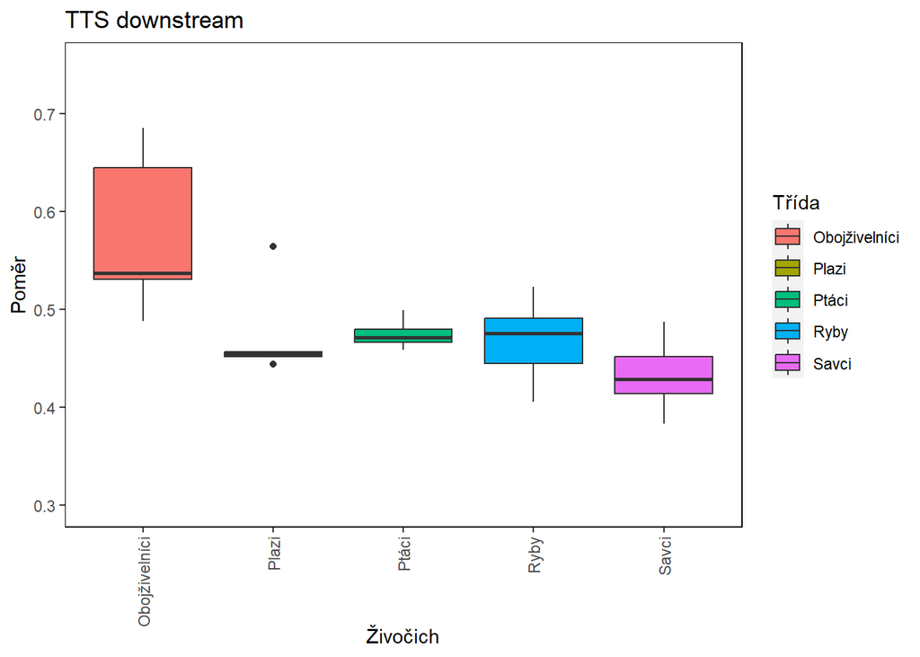

```
##
##  Kruskal-Wallis rank sum test
##
## data:  value by Třída
## Kruskal-Wallis chi-squared = 23.355, df = 4, p-value = 0.0001075
```

Dunnův test TTSdown

| Srovnání | Z | p-hodnota | Holm-Bonferonniho korekce |
| --- | --- | --- | --- |
| Obojživelníci - Plazi | 2.3595064 | 0.0182993 | 0.1097956 |
| Obojživelníci - Ptáci | 2.0541146 | 0.0399646 | 0.1998230 |
| Plazi - Ptáci | -0.7126520 | 0.4760611 | 1.0000000 |
| Obojživelníci - Ryby | 2.7258117 | 0.0064144 | 0.0449005 |
| Plazi - Ryby | -0.2984618 | 0.7653507 | 0.7653507 |
| Ptáci - Ryby | 0.6467856 | 0.5177707 | 1.0000000 |
| Obojživelníci - Savci | 4.5075885 | 0.0000066 | 0.0000656 |
| Plazi - Savci | 1.6432563 | 0.1003299 | 0.4013196 |
| Ptáci - Savci | 3.0788223 | 0.0020782 | 0.0187039 |
| Ryby - Savci | 2.9600305 | 0.0030761 | 0.0246087 |

## Signalizace a buněčné procesy

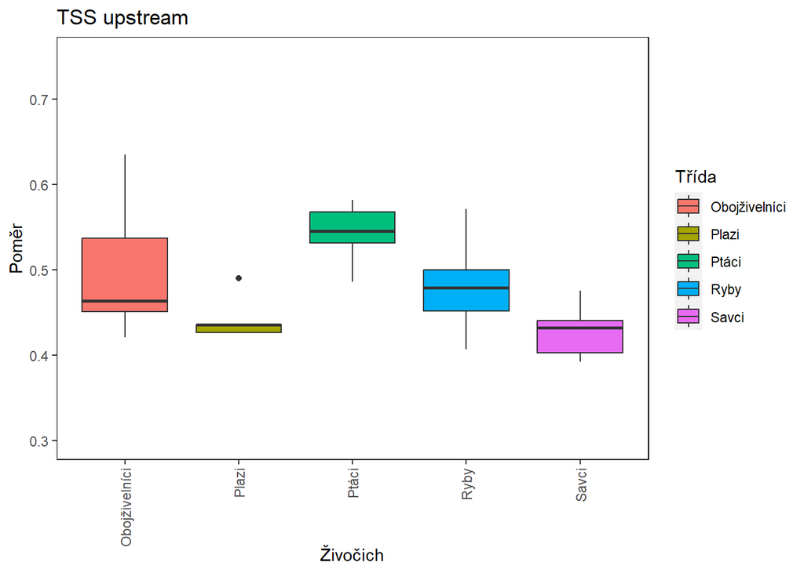

```
##
##  Kruskal-Wallis rank sum test
##
## data:  value by Třída
## Kruskal-Wallis chi-squared = 30.951, df = 4, p-value = 3.132e-06
```

Dunnův test TSSup

| Srovnání | Z | p-hodnota | Holm-Bonferonniho korekce |
| --- | --- | --- | --- |
| Obojživelníci - Plazi | 1.4980993 | 0.1341074 | 0.4023223 |
| Obojživelníci - Ptáci | -1.7526847 | 0.0796561 | 0.3982807 |
| Plazi - Ptáci | -3.5093619 | 0.0004492 | 0.0040426 |
| Obojživelníci - Ryby | 0.2254117 | 0.8216590 | 0.8216590 |
| Plazi - Ryby | -1.6947620 | 0.0901206 | 0.3604823 |
| Ptáci - Ryby | 2.8821226 | 0.0039501 | 0.0276504 |
| Obojživelníci - Savci | 2.2619131 | 0.0237028 | 0.1422166 |
| Plazi - Savci | 0.4432895 | 0.6575563 | 1.0000000 |
| Ptáci - Savci | 5.2710277 | 0.0000001 | 0.0000014 |
| Ryby - Savci | 3.1482876 | 0.0016423 | 0.0131384 |

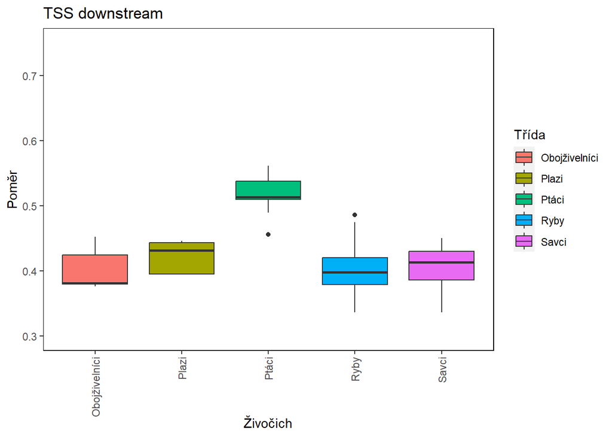

```
##
##  Kruskal-Wallis rank sum test
##
## data:  value by Třída
## Kruskal-Wallis chi-squared = 27.914, df = 4, p-value = 1.298e-05
```

Dunnův test TSSdown

| Srovnání | Z | p-hodnota | Holm-Bonferonniho korekce |
| --- | --- | --- | --- |
| Obojživelníci - Plazi | -0.9924908 | 0.3209582 | 1.0000000 |
| Obojživelníci - Ptáci | -3.3835998 | 0.0007154 | 0.0057234 |
| Plazi - Ptáci | -2.2198011 | 0.0264323 | 0.1850259 |
| Obojživelníci - Ryby | 0.0573965 | 0.9542294 | 0.9542294 |
| Plazi - Ryby | 1.3295115 | 0.1836793 | 1.0000000 |
| Ptáci - Ryby | 5.0555266 | 0.0000004 | 0.0000043 |
| Obojživelníci - Savci | -0.4384182 | 0.6610832 | 1.0000000 |
| Plazi - Savci | 0.7664199 | 0.4434265 | 1.0000000 |
| Ptáci - Savci | 3.9625760 | 0.0000741 | 0.0006673 |
| Ryby - Savci | -0.7573685 | 0.4488291 | 1.0000000 |

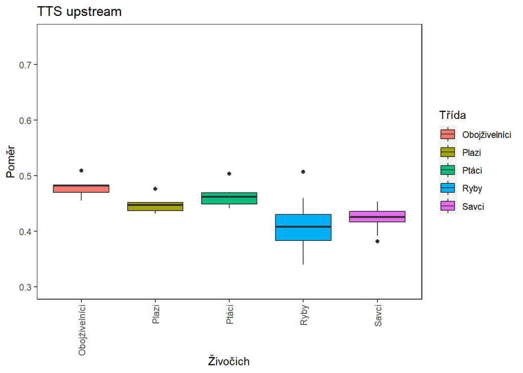

```
##
##  Kruskal-Wallis rank sum test
##
## data:  value by Třída
## Kruskal-Wallis chi-squared = 30.075, df = 4, p-value = 4.725e-06
```

Dunnův test TTSup

| Srovnání | Z | p-hodnota | Holm-Bonferonniho korekce |
| --- | --- | --- | --- |
| Obojživelníci - Plazi | 1.4231944 | 0.1546798 | 0.6187193 |
| Obojživelníci - Ptáci | 0.8324254 | 0.4051689 | 0.4051689 |
| Plazi - Ptáci | -0.8364179 | 0.4029199 | 0.8058397 |
| Obojživelníci - Ryby | 4.0501054 | 0.0000512 | 0.0004608 |
| Plazi - Ryby | 2.2259404 | 0.0260182 | 0.1561090 |
| Ptáci - Ryby | 4.2267727 | 0.0000237 | 0.0002371 |
| Obojživelníci - Savci | 3.1874626 | 0.0014353 | 0.0114822 |
| Plazi - Savci | 1.4597702 | 0.1443532 | 0.7217662 |
| Ptáci - Savci | 3.0072439 | 0.0026363 | 0.0184540 |
| Ryby - Savci | -0.9966232 | 0.3189475 | 0.9568424 |

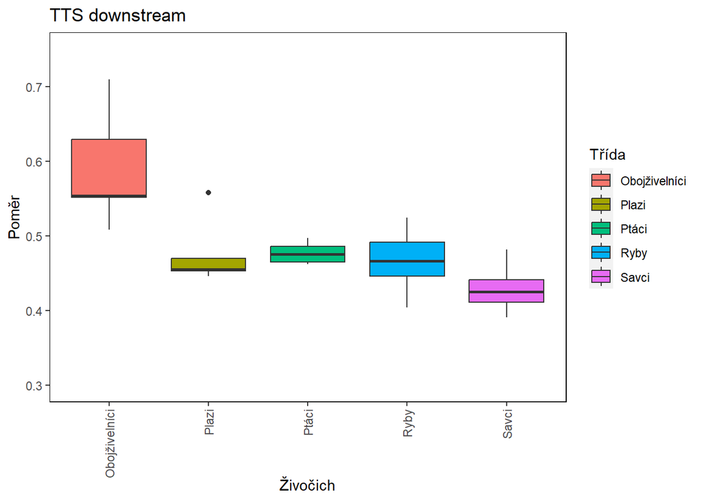

```
##
##  Kruskal-Wallis rank sum test
##
## data:  value by Třída
## Kruskal-Wallis chi-squared = 25.27, df = 4, p-value = 4.439e-05
```

Dunnův test TTSdown

| Srovnání | Z | p-hodnota | Holm-Bonferonniho korekce |
| --- | --- | --- | --- |
| Obojživelníci - Plazi | 2.3407802 | 0.0192435 | 0.1154610 |
| Obojživelníci - Ptáci | 2.1339635 | 0.0328458 | 0.1642288 |
| Plazi - Ptáci | -0.6108446 | 0.5413025 | 1.0000000 |
| Obojživelníci - Ryby | 2.8719119 | 0.0040800 | 0.0285598 |
| Plazi - Ryby | -0.1283594 | 0.8978645 | 0.8978645 |
| Ptáci - Ryby | 0.7259578 | 0.4678647 | 1.0000000 |
| Obojživelníci - Savci | 4.6943222 | 0.0000027 | 0.0000267 |
| Plazi - Savci | 1.8527228 | 0.0639221 | 0.2556884 |
| Ptáci - Savci | 3.2133895 | 0.0013118 | 0.0118060 |
| Ryby - Savci | 3.0343568 | 0.0024105 | 0.0192839 |

# IR kolem a uvnitř Features

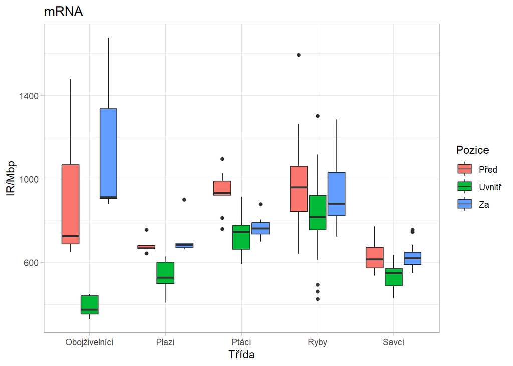

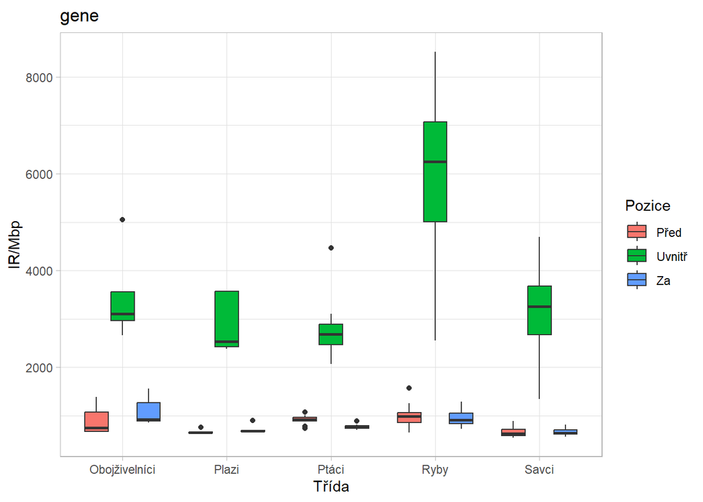

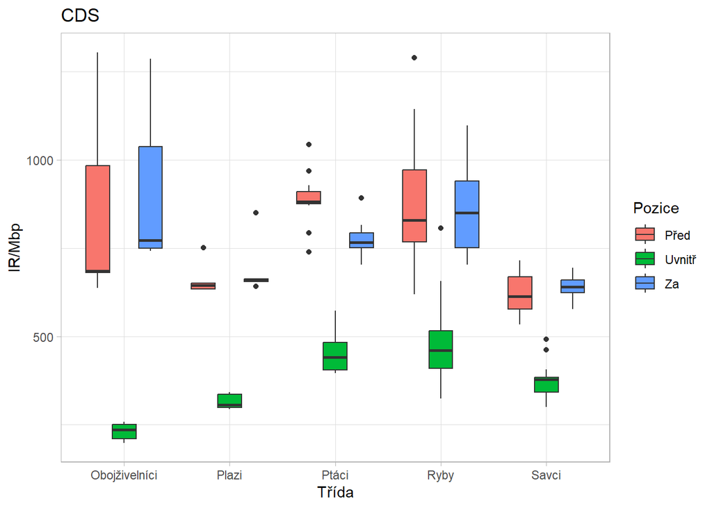

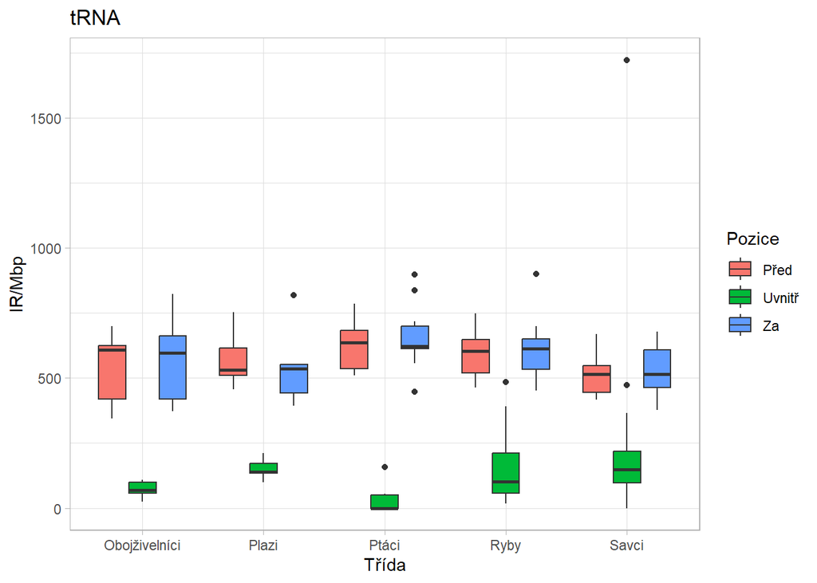

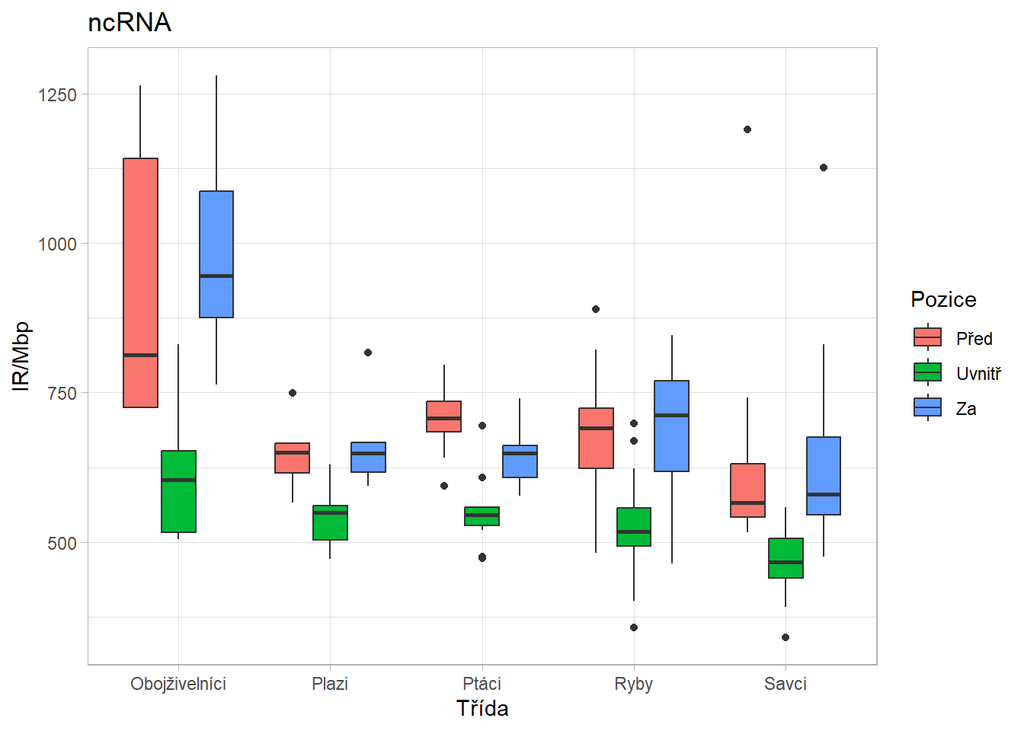

# IR u Features

Pomocí IR2Feature.py jsem vytvořil csv soubory, které jsou strukturně podobné TSS/TTS souborům, ale místo genů obsahují různé features, skript zároveň vytváří u všech živočichů soubor “All_features.csv”, který obsahuje všechny features daného organismu (typ, start pozice, end pozice, vlákno, délka), ten bude použit pro určení frekvence výskytu IR v těchto oblastech. Vybral jsem 10 features, které se vyskytují často a pomocí skriptu Feature_sum.py jsem vytvořil soubor “IR_features_summary.csv”, který obsahuje celkové počty těchto features pro každý organismus.

Vytvořím skript, který vezme ty počty IR u features a vydělí je délkami sekvencí v nichž se vyskytují, u startu a endu to bude 1000*počet features toho typu a u inside to bude součet délek všech features toho typu. Díky tomu budu moci porovnat frekvenci výskytu mezi živočichy a zároveň s předchozími analýzami. Problém je že se features překrývají, ale když se překrývají, tak se repetice v jejich blízkosti budou počítat 2 a více krát (pro každou feature jednou), výjde to stejně? Nevím jaký poměr použít, sum(IRs)/sum(feature length) nebo sum((ir/feature length)/feature count, příkláním se k tomu prvnímu.

Nastal problem s určenim delek bude nutne použit CompoundLocation a znovu to cele projet :(

Hotovo: nakonec používám počet unikátních IR dělený sjednocenou množinou pouzic obsazených tou feature (překryvy se počítájí jen jednou) U genů je však divná frekvence, nějak vysoká… Předělal jsem Feature_sum.py na Feature_sum2.0.py

# IR podle délek

Vytvořím skript, který projede všechny chromozomy ve složce “Filtered IR” a vytvoří soubor, který bude obsahovat počty repetic podle délek: [10-14,15-19,20-29,30-50] pro každý chromozom (udělat pak i podobný skript pro Features). Poté vytvořím skriptík, který to všechno nacpe do Latinský_název.xlsx a přidá i frekvence a upravím All_summaries_to_one_file.py aby tam zahrnoval ty další sloupečky.